# Assignment 03

Kevin Hu

26/09/2019

```r
library(gapminder)
library(tidyverse)
library(scales)
```

### Task 1: Get the maximum and minimum of GDP per capita for all continents

This task can be achieved by the following codes, and the results are shown below.

```r
gapminder %>%
  group_by(continent) %>%
  summarize(maximum = max(gdpPercap),
            minimum = min(gdpPercap))
```

```
## # A tibble: 5 x 3
##   continent maximum minimum
##   <fct>       <dbl>   <dbl>
## 1 Africa     21951.    241.
## 2 Americas   42952.   1202.
## 3 Asia      113523.    331
## 4 Europe     49357.    974.
## 5 Oceania    34435.  10040.
```

### Task 2: Look at the spread of GDP per capita within the continents

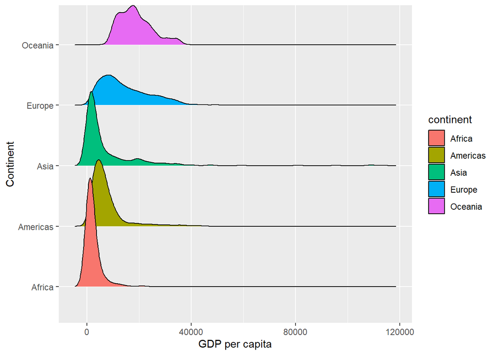

```r
gapminder %>%
  ggplot(aes(gdpPercap, continent, fill = continent)) +
  labs(x = "GDP per capita", y = "Continent") +
  ggridges::geom_density_ridges()
```

However, the grap above is visually skewed to the left. This does not represent the data as intented. In task 1, we knew the ranges between coninents are very different. Asia has a outstanding maximum, while Oceania has a minmum in different order of magnitude compared to others. Therefore, it is better to display each density plot saperately with different x axes.

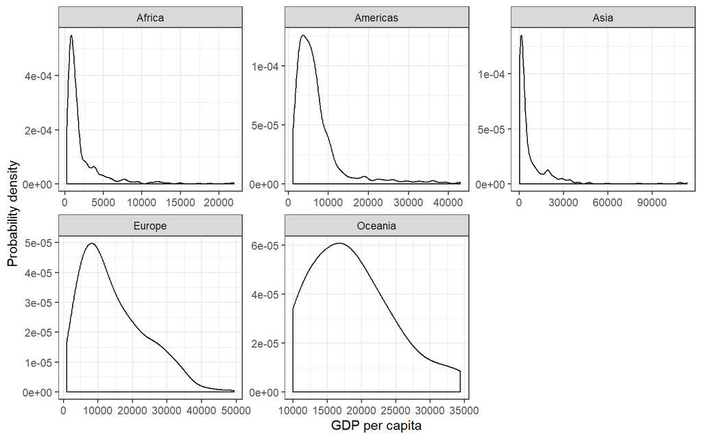

```r
gapminder %>%
  ggplot(aes(gdpPercap)) +
  labs(x = "GDP per capita", y = "Probability density") +
  geom_density()+
  facet_wrap(~ continent, scales = "free")+
  theme_bw()
```

### Task 3: How is life expectancy changing over time on different continents?

This can be achieved by plotting time series for all countries, then split by continent using the facet function.

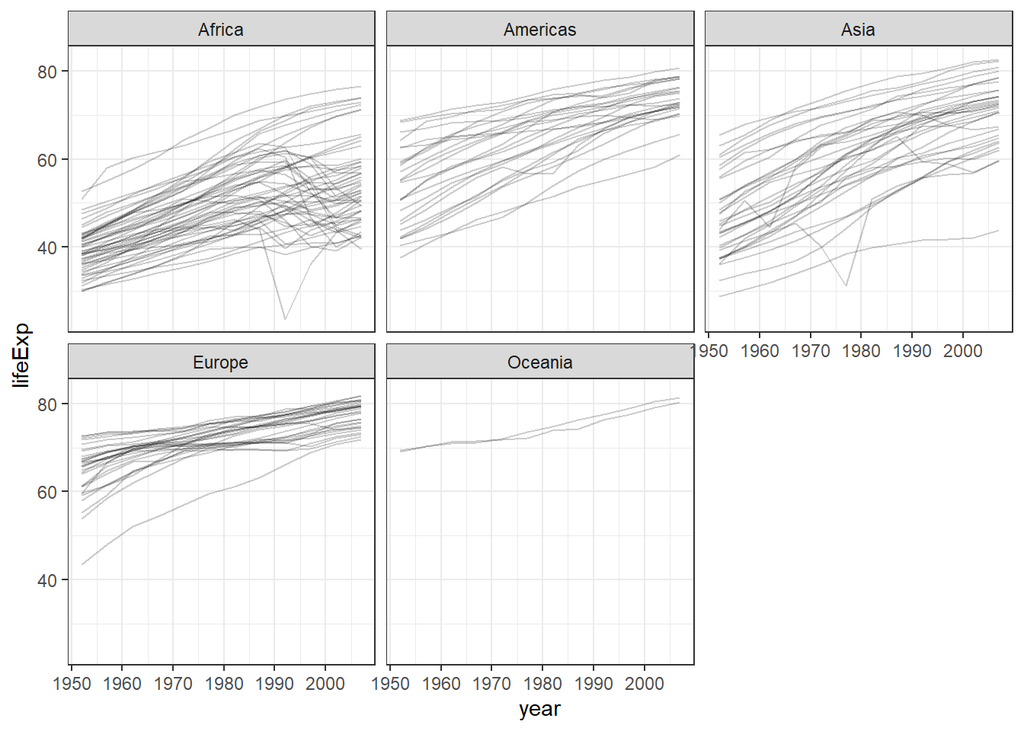

```r
gapminder %>%
  ggplot(aes(year, lifeExp, group = country)) +
  geom_line(alpha = 0.2) +
  facet_wrap(~ continent)+
  theme_bw()
```

In general, the life expentancy were increasing in all continents. A few counties in Africa, Americas, and Asia experienced some fluctuations.